# WeRateDogs Dataset

## Introduction

The dataset is the tweet archive of Twitter user @dog_rates, also known as WeRateDogs. WeRateDogs is a Twitter account that rates people's dogs with a humorous comment about the dog. These ratings almost always have a denominator of 10. The numerators, though? Almost always greater than 10. 11/10, 12/10, 13/10, etc. Why? Because "they're good dogs Brent." WeRateDogs has over 4 million followers and has received international media coverage.

## Analysis

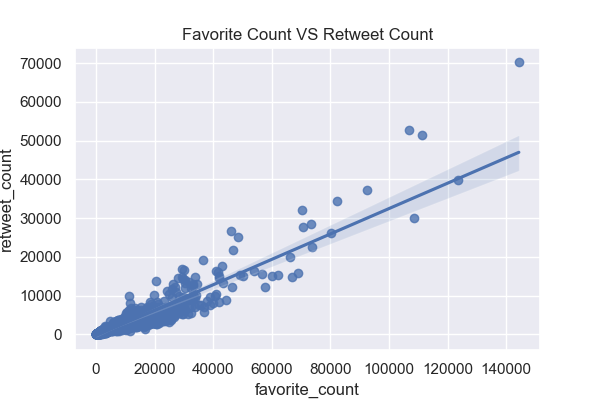

Further exploration shows that there's positive correlation between retweet counts and favourite counts in each weekday as shown below.

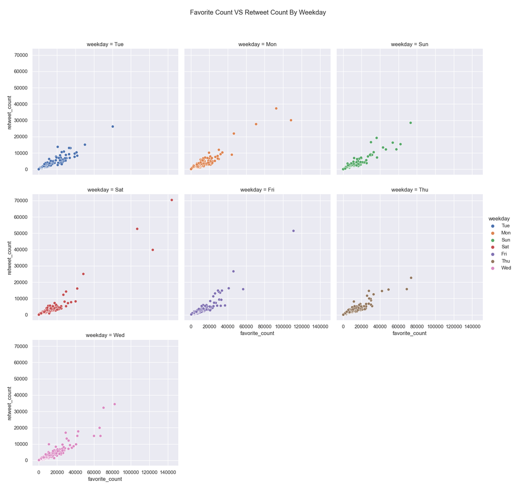

Still curious if there's disparity on the number of tweets made during the weekkdays. Plot below shows there's no much differences but monday seems to have more tweets.

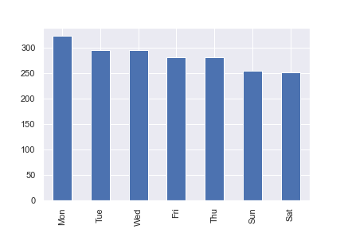

Lastly, here's a word cloud of one tweet inform of a dog.

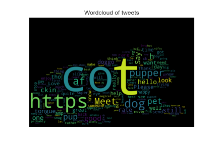